### 🔍 Resumo do dia 22/05 📊💡📈🚀

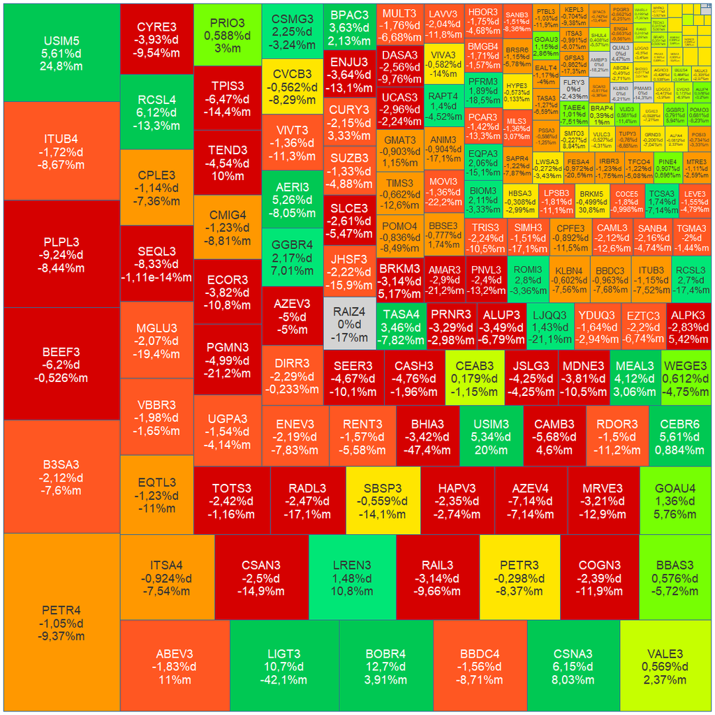

Maiores altas dos ativos mais representativos:

🟢 #BOBR4 12,7%  
🟢 #LIGT3 10,7%  
🟢 #CSNA3 6,15%  
🟢 #USIM5 5,61%  
🟢 #LREN3 1,48%

Maiores quedas dos ativos mais representativos:

🔴 #PLPL3 -9,24%  
🔴 #BEEF3 -6,2%  
🔴 #B3SA3 -2,12%  
🔴 #ABEV3 -1,83%  
🔴 #ITUB4 -1,72%

Maiores volumes em 22/05:

🔴 #PETR4 -1,05% R$ 39,63 Mi

🔴 #B3SA3 -2,12% R$ 31,89 Mi

🔴 #BEEF3 -6,2% R$ 29,04 Mi

🔴 #ABEV3 -1,83% R$ 24,01 Mi

🟢 #USIM5 5,61% R$ 22,52 Mi

a seguir, treemap dos volumes:

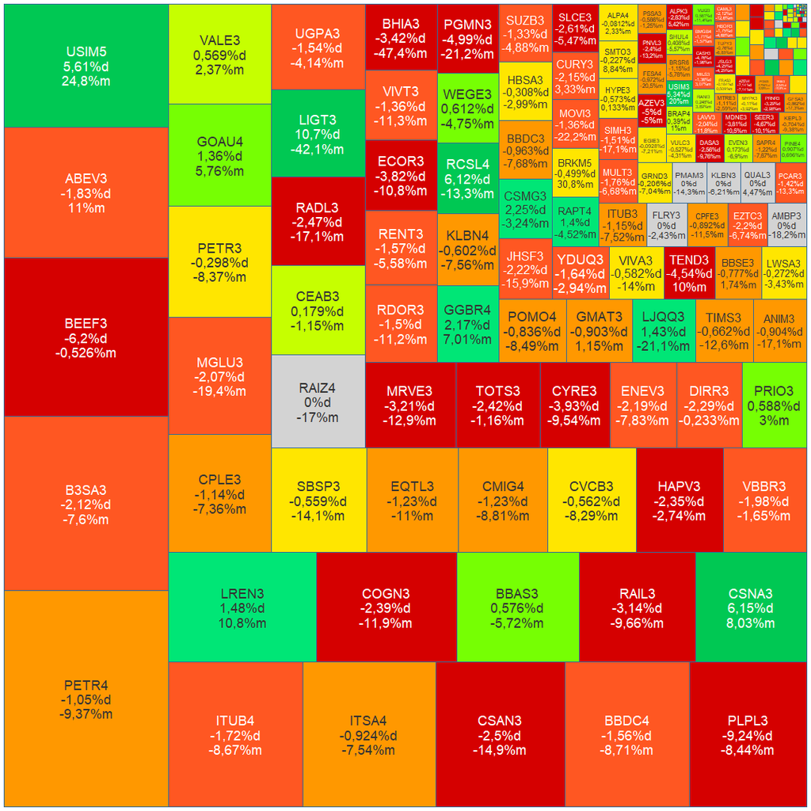

E assim concluímos nossa jornada diária pelos caminhos do mercado financeiro brasileiro. 📊💼 Espero que esses breves insights tenham contribuído e inspirado novas perspectivas sobre o mercado. Mas a conversa não termina aqui! 💬🌐 Convidamos todos vocês a compartilhar suas próprias análises, estratégias e pensamentos nos comentários. Afinal, é através do intercâmbio de ideias que todos nós prosperamos como investidores e membros desta comunidade vibrante. Fiquem atentos para mais análises e discussões amanhã. Até lá, que seus investimentos sejam sólidos e suas decisões informadas. 🚀🔍 Juntos, vamos além dos números e construímos um entendimento mais profundo dos mercados!

#Ibovespa #AnáliseDiária #Investimentos #ComunidadeFinanceira

*Exoneração de responsabilidade*: as informações e análises contidas neste material são de caráter meramente informativo e educacional, baseadas em dados estatísticos e análise técnica do mercado financeiro. Este material não constitui e não deve ser interpretado como uma recomendação de investimento, aconselhamento financeiro ou oferta de compra ou venda de quaisquer ativos financeiros. O autor deste material não se responsabiliza por quaisquer perdas ou danos decorrentes do uso das informações aqui apresentadas. O investimento em ações e outros ativos financeiros envolve riscos significativos, e o desempenho passado não garante resultados futuros. Cada investidor é responsável por suas próprias decisões de investimento, devendo buscar orientação de profissionais qualificados antes de tomar qualquer decisão. As análises e insights apresentados neste material refletem insights sistêmicos em um determinado momento e estão sujeitos a alterações sem aviso prévio. O autor não garante a precisão, integridade ou atualidade das informações aqui fornecidas, e não se responsabiliza por eventuais erros ou omissões. Ao utilizar este material, você concorda em isentar o autor de qualquer responsabilidade por quaisquer perdas ou danos, diretos ou indiretos, decorrentes do uso das informações aqui contidas